# R Notebook

# Research Question

Enrique “Kike” Hernández is widely regarded for his exceptional postseason performances. While his regular-season statistics are often overlooked compared to other players, this is rightfully so, as his postseason success is what truly stands out. His playoff performances place him among the greatest postseason hitters in recent history. My research aims to investigate the dramatic difference between his regular-season and postseason play, focusing on splits such as RHP vs LHP, home vs away, and fastball vs other pitches. This analysis explores whether Kike’s postseason success is a statistical anomaly or if he truly excels under pressure, highlighting his ability to elevate his game when it matters most.

# Narrative Text

**Reason why I want to investigate this topic**: The main reason I chose to investigate Kike Hernández’s postseason performance is to understand what makes him so successful in high-pressure situations. Unlike many players who struggle to replicate their regular-season success in the postseason, Kike consistently performs at an elite level when it matters most. This contrast between his regular-season and postseason statistics presents an unique opportunity to explore how different factors—such as performance against right-handed vs. left-handed pitchers, home vs. away games, and fastball vs. other pitches—might explain Kike’s remarkable postseason success. By analyzing his performance through these splits, I aim to identify patterns and factors that contribute to his ability to elevate his game in the postseason.

**One significant technical challenge**: One of the main challenges I faced during this project was merging and organizing data from different sources. Postseason and regular-season data came from separate datasets, and they needed to be carefully cleaned and aligned for accurate comparison. Additionally, finding the right metrics that captured Kike’s performance under pressure—while also filtering out the noise—required substantial data wrangling. After ensuring the datasets were properly combined and transformed, I was able to conduct a comprehensive analysis comparing Kike’s postseason and regular-season stats.

```r
library(dplyr)
library(tidyverse)
```

```r
library(tidyr)
library(ggplot2)

Kike_regular_lhp <- read.csv("/Users/jjwee/Downloads/Kike_regular_lhp.csv")
Kike_regular_rhp <- read.csv("/Users/jjwee/Downloads/Kike_regular_rhp.csv")
Kike_regularaway <- read.csv("/Users/jjwee/Downloads/Kike_regularaway.csv")
Kike_regularhome <- read.csv("/Users/jjwee/Downloads/Kike_regularhome.csv")
Kike_postseason_rhp <- read.csv("/Users/jjwee/Downloads/Kike_postseason_rhp.csv")
Kike_postseason_lhp <- read.csv("/Users/jjwee/Downloads/Kike_postseason_lhp.csv")
Kike_posthome<- read.csv("/Users/jjwee/Downloads/Kike_posthome.csv")
Kike_postseason_away<- read.csv("/Users/jjwee/Downloads/Kike_postseason_away.csv")
Kike_postseason_fb<- read.csv("/Users/jjwee/Downloads/Kike_postseason_fb.csv")
Kike_postseason_op<- read.csv("/Users/jjwee/Downloads/Kike_postseason_op.csv")
Kike_regular_op<- read.csv("/Users/jjwee/Downloads/Kike_regular_op.csv")
Kike_regular_fb<- read.csv("/Users/jjwee/Downloads/Kike_regular_fb.csv")
```

This code imports datasets on Kiké Hernández’s regular-season and postseason performances, split by pitcher handedness (LHP vs. RHP), game location (home vs. away), and pitch type (fastballs vs. off-speed). These datasets allow for a comparison of his performance across different conditions, emphasizing his postseason excellence relative to the regular season.

```r
# Combine all the metrics into a single dataframe, adding 'season' and 'condition'
all_metrics <- bind_rows(
  mutate(Kike_regular_lhp, season = "Regular", condition = "Regular LHP"),
  mutate(Kike_regular_rhp, season = "Regular", condition = "Regular RHP"),
  mutate(Kike_regularaway, season = "Regular", condition = "Regular Away"),
  mutate(Kike_regularhome, season = "Regular", condition = "Regular Home"),
  mutate(Kike_postseason_lhp, season = "Postseason", condition = "Postseason LHP"),
  mutate(Kike_postseason_rhp, season = "Postseason", condition = "Postseason RHP"),
  mutate(Kike_postseason_away, season = "Postseason", condition = "Postseason Away"),
  mutate(Kike_posthome, season = "Postseason", condition = "Postseason Home"),
  mutate(Kike_postseason_fb, season = "Postseason", condition = "Postseason Fastball"),
  mutate(Kike_postseason_op, season = "Postseason", condition = "Postseason Other Pitches"),
  mutate(Kike_regular_fb, season = "Regular", condition = "Regular Fastball"),
  mutate(Kike_regular_op, season = "Regular", condition = "Regular Other Pitches")
)

# View the metrics summary (optional)
print(all_metrics)
```

```
##    pitches player_id        player_name total_pitches pitch_percent    ba   iso
## 1     5069    571771 Hernández, Enrique         12910          39.3 0.252 0.196
## 2     7841    571771 Hernández, Enrique         12910          60.7 0.227 0.151
## 3     6690    571771 Hernández, Enrique         12910          51.8 0.223 0.155
## 4     6220    571771 Hernández, Enrique         12910          48.2 0.250 0.182
## 5      340    571771 Hernández, Enrique           894          38.0 0.239 0.239
## 6      554    571771 Hernández, Enrique           894          62.0 0.312 0.283
## 7      449    571771 Hernández, Enrique           894          50.2 0.343 0.314
## 8      445    571771 Hernández, Enrique           894          49.8 0.231 0.221
## 9      549    571771 Hernández, Enrique           894          61.4 0.257 0.169
## 10     345    571771 Hernández, Enrique           894          38.6 0.342 0.452
## 11    7256    571771 Hernández, Enrique         12910          56.2 0.251 0.178
## 12    5586    571771 Hernández, Enrique         12910          43.3 0.216 0.151
##    babip   slg  woba xwoba   xba hits  abs launch_speed launch_angle spin_rate
## 1  0.267 0.447 0.332 0.335 0.254  280 1113         89.6         15.7      2157
```

[output cut: 154 more lines]

This code combines multiple datasets on Kiké Hernández’s regular-season and postseason performances into a single dataframe, adding columns for ‘season’ and ‘condition’ to distinguish between different conditions (pitcher handedness, game location, and pitch type). This allows for an easy comparison of his performance across various factors.

# First, I compared Kike Hernández’s performance at Home vs Away in both the Postseason and Regular Season.

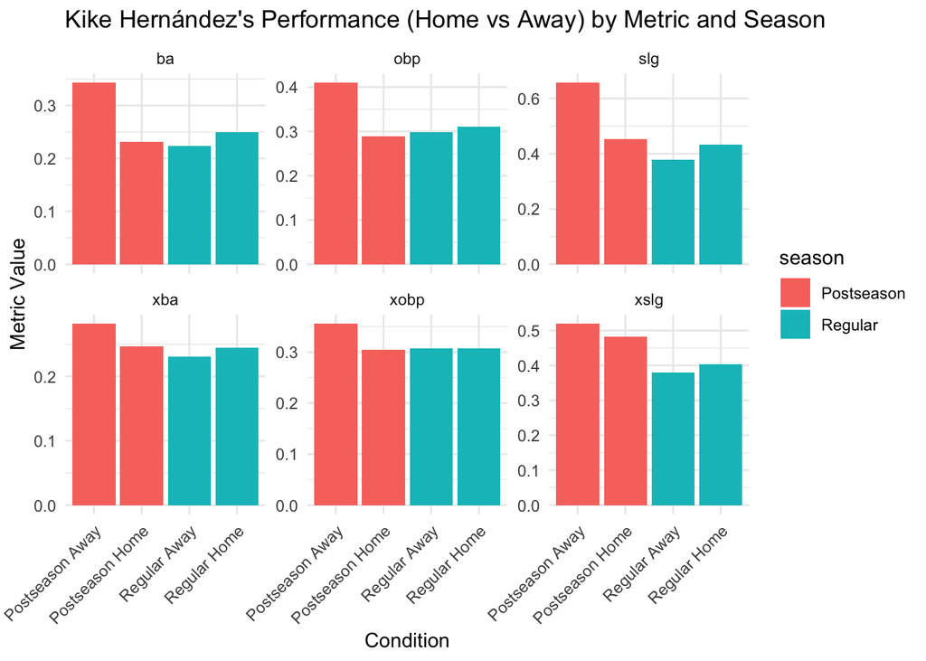

```r
# Filter the data to include only Home and Away conditions for both Postseason and Regular Season
all_metrics_filtered <- all_metrics %>%
  filter(condition %in% c("Regular Home", "Regular Away", "Postseason Home", "Postseason Away"))

# Pivot all metrics into long format for easier plotting
all_metrics_long <- all_metrics_filtered %>%
  pivot_longer(cols = c(ba, slg, obp, xba, xobp, xslg),
               names_to = "metric",
               values_to = "value")



# Plot all metrics (Home vs Away for Regular and Postseason) in a single graph
ggplot(all_metrics_long, aes(x = condition, y = value, fill = season)) +
  geom_bar(stat = "identity", position = "dodge") +
  facet_wrap(~ metric, scales = "free_y") +  # Separate plot for each metric
  theme_minimal() +
  labs(title = "Kike Hernández's Performance (Home vs Away) by Metric and Season",
       x = "Condition", y = "Metric Value") +
  theme(axis.text.x = element_text(angle = 45, hjust = 1))
```

This visualization highlights Kiké Hernández’s performance across home and away splits, comparing his postseason and regular-season stats. The data reveals that Hernández performs exceptionally well in postseason away games, where he outshines all other splits across the six metrics analyzed.

Overall, this analysis underscores Hernández’s ability to deliver under pressure, particularly in high-stakes postseason away games, where his performance reaches its peak.

# Next, I compared Kike Hernández’s performance against Right-Handed Pitchers (RHP) and Left-Handed Pitchers (LHP) in both the Postseason and Regular Season.

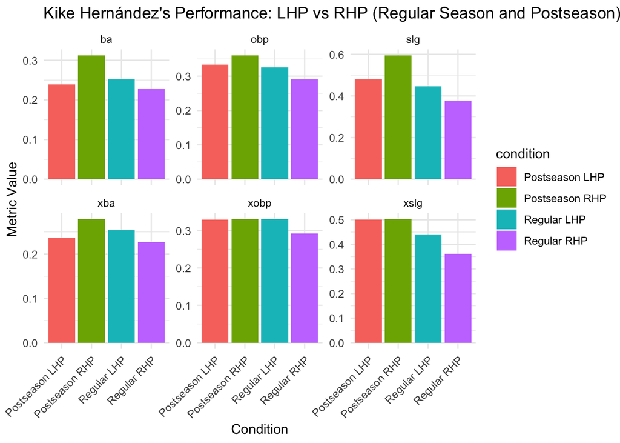

```r
# Filter the data to include only Regular and Postseason LHP and RHP
all_metrics_filtered <- all_metrics %>%
  filter(condition %in% c("Postseason LHP", "Postseason RHP", "Regular LHP", "Regular RHP"))

# Pivot all metrics into long format for easier plotting
all_metrics_long <- all_metrics_filtered %>%
  pivot_longer(cols = c(ba, slg, obp, xba, xobp, xslg),
               names_to = "metric",
               values_to = "value")

# Plot metrics comparing LHP vs RHP for both Regular Season and Postseason
ggplot(all_metrics_long, aes(x = condition, y = value, fill = condition)) +
  geom_bar(stat = "identity", position = "dodge") +
  facet_wrap(~ metric, scales = "free_y") +  # Separate plot for each metric
  theme_minimal() +
  labs(title = "Kike Hernández's Performance: LHP vs RHP (Regular Season and Postseason)",
       x = "Condition", y = "Metric Value") +
  theme(axis.text.x = element_text(angle = 45, hjust = 1))
```

This visualization showcases Kiké Hernández’s performance during the postseason and regular season, categorized by pitching hand type. The data highlights that Hernández excelled against right-handed pitchers in the postseason, particularly in BA and SLG. Interestingly, his xOBP and xSLG during the postseason are nearly identical when facing right- and left-handed pitchers.

# Finally, this analysis compares Kike Hernández’s performance against Fastballs and Other Pitches (including Changeups, Curveballs, Sliders, etc.) in the Postseason and Regular Season.

```r
# Check the unique values in the 'condition' column to verify the correct labels
unique(all_metrics$condition)
```

```
##  [1] "Regular LHP"              "Regular RHP"
##  [3] "Regular Away"             "Regular Home"
##  [5] "Postseason LHP"           "Postseason RHP"
##  [7] "Postseason Away"          "Postseason Home"
##  [9] "Postseason Fastball"      "Postseason Other Pitches"
## [11] "Regular Fastball"         "Regular Other Pitches"
```

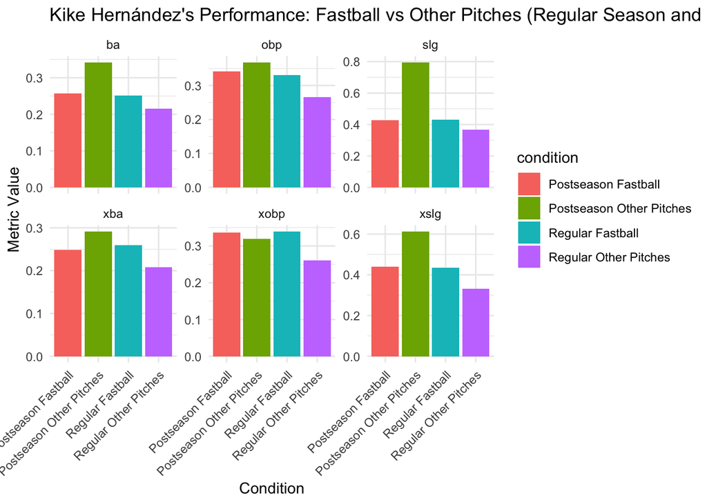

```r
# Filter the data to include only Fastball and Other pitches for both Postseason and Regular Season
all_metrics_filtered <- all_metrics %>%
  filter(grepl("Fastball|Other", condition))  # Use grepl to match "Fastball" or "Other"

# Pivot all metrics into long format for easier plotting
all_metrics_long <- all_metrics_filtered %>%
  pivot_longer(cols = c(ba, slg, obp, xba, xobp, xslg),
               names_to = "metric",
               values_to = "value")

# Plot metrics comparing Fastball vs Other Pitches for both Regular Season and Postseason
ggplot(all_metrics_long, aes(x = condition, y = value, fill = condition)) +
  geom_bar(stat = "identity", position = "dodge") +
  facet_wrap(~ metric, scales = "free_y") +  # Separate plot for each metric
  theme_minimal() +
  labs(title = "Kike Hernández's Performance: Fastball vs Other Pitches (Regular Season and Postseason)",
       x = "Condition", y = "Metric Value") +
  theme(axis.text.x = element_text(angle = 45, hjust = 1))
```

This visualization highlights Kiké Hernández’s performance against fastballs and other pitch types, comparing postseason and regular-season stats. The data shows that Hernández excelled against non-fastball pitches during the postseason, with SLG and xSLG standing out as particularly impressive. This contrasts sharply with his regular-season performance, where he struggled significantly against non-fastball pitches.